# Overview of Some Machine Learning Methods in R

# Feature Selection

#### - Given a response variable, which subset of predictor variables is best for prediction?

#### - Need 2 things:

#### - A strategy for searching (**best subsets, forward stepwise, backward stepwise**)

#### - A selection criteria (**adjusted R-squared, AIC, BIC, CP, CV**)

#### - Best subsets considers all models and thus produces lowest RSS

#### - Smaller AIC is better

#### - CP rewards models that make MSE smaller but adds a penalty for models that add variables. It is also an unbiased estimate of the testing MSE. It uses a coefficient of 2 to penalize models.

#### - For LS regression, if errors are gaussian then AIC is proportional to CP so they will choose the same models (with smaller values)

#### - BIC penalizes for larger sample sizes. Smaller BIC is better. It uses a coefficient of log(n) to penalize models.

#### - CV makes the least amount of assumptions about the model in terms of the selection criterias

```r
library(leaps)
library(caret)
train.data <- read.csv('boston.train.csv')

test.data <- read.csv('boston.test.csv')


predict.regsubsets = function(object, newdata, id, ...) {
    form = as.formula(object$call[[2]])
    mat = model.matrix(form, newdata)
    coefi = coef(object, id = id)
    mat[, names(coefi)] %*% coefi
} #R has no predict function for regsubsets

#Regsubsets searching
#For Forwards and Backwards: specify "method" argument in regsubsets()
models <- regsubsets(crim~., data = train.data, nvmax = 14)
summary(models)
```

```
## Subset selection object
## Call: regsubsets.formula(crim ~ ., data = train.data, nvmax = 14)
## 13 Variables  (and intercept)
##         Forced in Forced out
## zn          FALSE      FALSE
## indus       FALSE      FALSE
## chas        FALSE      FALSE
## nox         FALSE      FALSE
## rm          FALSE      FALSE
## age         FALSE      FALSE
## dis         FALSE      FALSE
## rad         FALSE      FALSE
## tax         FALSE      FALSE
## ptratio     FALSE      FALSE
## black       FALSE      FALSE
## lstat       FALSE      FALSE
## medv        FALSE      FALSE
## 1 subsets of each size up to 13
## Selection Algorithm: exhaustive
##           zn  indus chas nox rm  age dis rad tax ptratio black lstat medv
## 1  ( 1 )  " " " "   " "  " " " " " " " " "*" " " " "     " "   " "   " "
## 2  ( 1 )  " " " "   " "  " " " " " " " " "*" " " " "     " "   "*"   " "
## 3  ( 1 )  " " " "   " "  " " " " " " " " "*" " " " "     "*"   "*"   " "
## 4  ( 1 )  "*" " "   " "  " " " " " " " " "*" " " " "     "*"   "*"   " "
## 5  ( 1 )  "*" " "   " "  " " "*" " " " " "*" " " " "     "*"   "*"   " "
## 6  ( 1 )  "*" " "   " "  "*" " " " " "*" "*" " " " "     "*"   "*"   " "
## 7  ( 1 )  "*" " "   " "  "*" "*" " " "*" "*" " " " "     "*"   "*"   " "
## 8  ( 1 )  "*" "*"   " "  "*" "*" " " "*" "*" " " " "     "*"   "*"   " "
## 9  ( 1 )  "*" "*"   "*"  "*" "*" " " "*" "*" " " " "     "*"   "*"   " "
## 10  ( 1 ) "*" "*"   "*"  "*" "*" " " "*" "*" " " "*"     "*"   "*"   " "
## 11  ( 1 ) "*" "*"   "*"  "*" "*" " " "*" "*" " " "*"     "*"   "*"   "*"
## 12  ( 1 ) "*" "*"   "*"  "*" "*" "*" "*" "*" " " "*"     "*"   "*"   "*"
## 13  ( 1 ) "*" "*"   "*"  "*" "*" "*" "*" "*" "*" "*"     "*"   "*"   "*"
```

```r
data.frame(
  adjusted_r2 = which.max(summary(models)$adjr2),
  CP = which.min(summary(models)$cp),
  BIC = which.min(summary(models)$bic)
)
```

```
##   adjusted_r2 CP BIC
## 1           9  8   3
```

```r
coef(models, 8) #coefficients for model selected by CP criteria
```

```
## (Intercept)          zn       indus         nox          rm         dis
## 14.93962853  0.03944586 -0.10128760 -7.17595070 -1.19778218 -0.72897224
##         rad       black       lstat
##  0.43584785 -0.01002218  0.20347015
```

```r
prediction.cp <- predict.regsubsets(models, newdata=test.data, id=8)
mse.cp <- mean((prediction.cp - test.data$crim)^2)
mse.cp #MSE for model selected by CP criteria
```

```
## [1] 82.49914
```

```r
coef(models, 3) #coefficients for model selected by BIC criteria
```

```
##  (Intercept)          rad        black        lstat
## -0.450114002  0.401203242 -0.008855665  0.232101736
```

```r
prediction.bic <- predict.regsubsets(models, newdata=test.data, id=3)
mse.bic <- mean((prediction.bic - test.data$crim)^2)
mse.bic #MSE for model selected by BIC criteria
```

```
## [1] 82.08559
```

```r
#CV method for selection criteria
set.seed(123)
k <- 10
n <- nrow(train.data)
folds <- sample(1:k, n, replace = T)
cv.error.matrix <- matrix(NA,k,13)

train.data <- na.omit(train.data)
for(j in 1:k){
  best.fit <- regsubsets(crim~.,data=train.data[folds!=j,], nvmax=13)
  for(i in 1:13){
    prediction <- predict(best.fit, train.data[folds==j,], id = i)
    cv.error.matrix[j,i] = mean((train.data$crim[folds==j]-prediction)^2)

  }
}

average.mse <- apply(cv.error.matrix,2,mean)
which.min(average.mse) #Number of parameters chosen by 10-fold cv
```

```
## [1] 9
```

```r
coef(models, 9)
```

```
##  (Intercept)           zn        indus         chas          nox
## 14.910929248  0.038920111 -0.100114669 -1.074968885 -7.230347019
##           rm          dis          rad        black        lstat
## -1.176000927 -0.742786962  0.435313610 -0.009808787  0.201032057
```

```r
prediction.cv <- predict(models, newdata=test.data, id=9)
mse.cv <- mean((prediction.cv-test.data$crim)^2)
mse.cv
```

```
## [1] 82.43036
```

# Model Selection Beyond Least Squares (but still linear)

# Ridge Regression

#### - Adds penalty term lambda to LS

#### - Variables approach 0

#### - All variables are standardized

#### - Variables with larger coefficients are considered more important

#### - Ridge can have lower MSE than LS, but is less variable than LS (because high-variable parameters are shrunk)

#### - No missing values

#### - No text variables

#### - Predictors in 1 matrix, response in a vector

#### - As lambda gets bigger, coefficients get smaller really fast, variability decreases and bias increases

#### - Variability decreases faster than bias increases

#### - Optimal lambda minimizes MSE (we measure MSE here through CV)

#### - Useful when p is large relative to n (i.e. helpful for smaller sample sizes)

```r
library(glmnet)
```

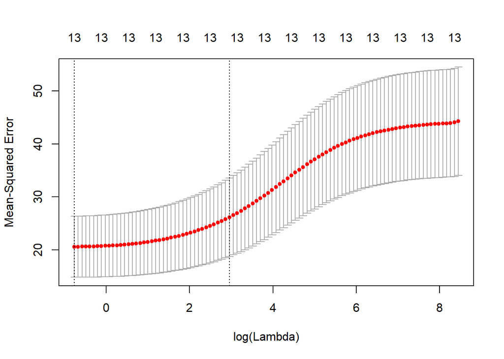

```r
set.seed(123)

#Remove NA's
train.data <- na.omit(train.data)

#Remove response variable in train data
x <- model.matrix(crim~., data = train.data)[,-1]
y <- train.data$crim

cv.ridge <- cv.glmnet(x,y, alpha = 0)
plot(cv.ridge)
```

```r
bestlam <- cv.ridge$lambda.min
bestlam
```

```
## [1] 0.4652447
```

```r
model.ridge <- glmnet(x,y,alpha = 0, lambda = bestlam)
coef(model.ridge)
```

```
## 14 x 1 sparse Matrix of class "dgCMatrix"
##                       s0
## (Intercept) 12.560800572
## zn           0.030246056
## indus       -0.090400105
## chas        -0.917310314
## nox         -5.306164163
## rm          -1.009386348
## age          0.007801889
## dis         -0.533046781
## rad          0.338408120
## tax          0.004093408
## ptratio     -0.053670836
## black       -0.009728294
## lstat        0.170059584
## medv        -0.021741211
```

```r
#Remove response variable in test data
xtest <- as.matrix(test.data)[,-1]
prediction.ridge <- predict(model.ridge, newx=xtest)
mse.ridge <- mean((prediction.ridge-test.data$crim)^2)
mse.ridge
```

```
## [1] 82.97535
```

# LASSO Regression

#### - Similar to ridge; uses the L1 norm

#### - Forces some variables to 0 and is thus good for model selection

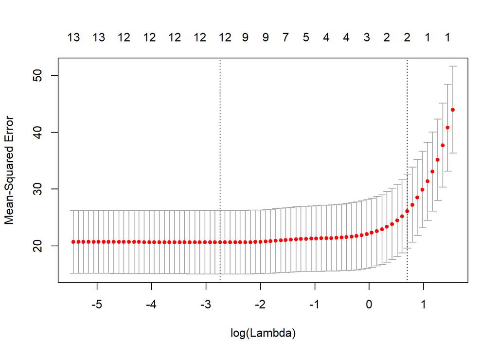

```r
cv.lasso <- cv.glmnet(x,y, alpha = 1)
plot(cv.lasso)
```

```r
bestlam <- cv.lasso$lambda.min #lowest lambda
bestlam
```

```
## [1] 0.0644311
```

```r
model.lasso <- glmnet(x,y,alpha = 1, lambda = bestlam)
coef(model.lasso)
```

```
## 14 x 1 sparse Matrix of class "dgCMatrix"
##                       s0
## (Intercept) 11.660961582
## zn           0.030359678
## indus       -0.066169738
## chas        -0.854466031
## nox         -4.548327538
## rm          -0.992451540
## age          0.001457434
## dis         -0.523589624
## rad          0.420545585
## tax          .
## ptratio     -0.023074128
## black       -0.009051774
## lstat        0.186261805
## medv        -0.006138095
```

```r
#Remove response variable in test data
xtest <- as.matrix(test.data)[,-1]
prediction.lasso <- predict(model.lasso, newx=xtest)
mse.lasso <- mean((prediction.lasso-test.data$crim)^2)
mse.lasso
```

```
## [1] 82.41755
```

# Principal Components Regression

#### - Reduce dimensions of p predictor variables in order to reduce flexibility and improve MSE

#### - No variables are dropped; Each m variable (where m < p) is a sum of all of the original p-variables

#### - Choose principal components by choosing the variables that point in the direction of maximum variation (as to retain as much info as possible)

#### - The # of principal components to keep is determined by which model produces the best testing MSE

#### - Example of Unsupervised learning because the PCs are determined without reference to the response variable

```r
#Split into train and test
set.seed(12345)
library(ISLR)
library(pls)
```

```r
mydata <- College

train <- sample(1:nrow(mydata), nrow(mydata)/2)
mydata.train <- mydata[train, ]
mydata.test <- mydata[-train, ]


#PCR
pcr.model <- pcr(Apps~., data = mydata.train, scale = TRUE, validation = 'CV')
summary(pcr.model) #Minimum at 17 on the plot
```

```
## Data:    X dimension: 388 17
##  Y dimension: 388 1
## Fit method: svdpc
## Number of components considered: 17
##
## VALIDATION: RMSEP
## Cross-validated using 10 random segments.
##        (Intercept)  1 comps  2 comps  3 comps  4 comps  5 comps  6 comps
## CV            3438     3327     1590     1526     1479     1234     1152
## adjCV         3438     3328     1589     1525     1478     1230     1148
##        7 comps  8 comps  9 comps  10 comps  11 comps  12 comps  13 comps
## CV        1133     1121     1103      1070      1076      1082      1083
## adjCV     1129     1119     1099      1065      1072      1078      1080
##        14 comps  15 comps  16 comps  17 comps
## CV         1073      1095     903.6     898.0
## adjCV      1069      1091     899.9     894.3
##
## TRAINING: % variance explained
##       1 comps  2 comps  3 comps  4 comps  5 comps  6 comps  7 comps
## X      33.179    58.94    66.00    71.66    76.99    81.67    85.06
## Apps    6.867    78.78    80.81    82.82    87.79    89.30    89.61
##       8 comps  9 comps  10 comps  11 comps  12 comps  13 comps  14 comps
## X       88.23    91.05     93.39     95.61     97.35     98.33     99.05
## Apps    90.14    90.78     91.15     91.25     91.28     91.31     91.47
##       15 comps  16 comps  17 comps
## X        99.50     99.85    100.00
## Apps     91.47     94.02     94.14
```

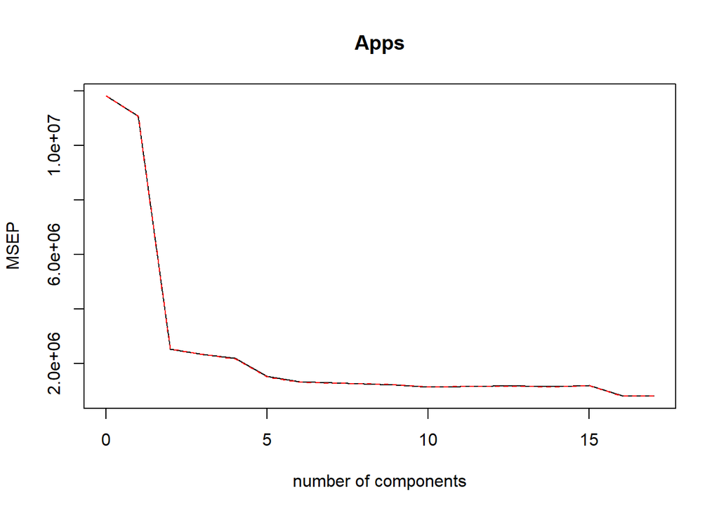

```r
validationplot(pcr.model, val.type = 'MSEP')
```

```r
#Remove response variable from test data
prediction.pcr <- predict(pcr.model, mydata.test[ ,-2], ncomp = 17)
mse <- mean((prediction.pcr - mydata.test$Apps)^2)
mse
```

```
## [1] 1678676
```